# Busq_Incre

## Ejercicio 2

**(5 puntos)**

Escribir una función **`raices(f,a,b,tol)`** que devuelve las raíces de $f$ en el intervalor $[a,b]$ con un error absoluto menor que $tol$ en un array numpy (vector). Seguir el siguiente procedimiento

1. Con la función **`busquedaIncremental(f,a,b,n)`** separa los ceros en intervalos de longitud $L=0.1$. Como $$L=\dfrac{b-a}{n}$$ usaremos $$n=\dfrac{b-a}{0.1}$$ en la función **`busquedaIncremental`**.
2. Una vez están separados los ceros, para cada cero, realizamos una serie de iteraciones usando **`busquedaIncremental(f,a0,b0,10)`** donde **`a0`** y **`b0`** son los bordes del último intervalo calculado. Cada vez que llamamos **`busquedaIncremental`** reducimos a una décima parte la longitud del último intervalo. Como la longitud del intervalo que contiene el cero es una cota del error absoluto, parar cuando su longitud sea menor que $tol.$ Para ello hay que realizar **`numiter = int(-np.log10(tol)-1)`** iteraciones.
3. Tomaremos como aproximación de la raíz **`a0`**, es decir, el borde inferior del último intervalo encontrado. Dibujar la función con el eje OX dentro de la función **`raices`**.

Usar

```
p = np.array([1., 0.2, -7., 0.7, 8])
f = lambda x: np.polyval(p,x)
```

con los valores **`a = -3`**, **`b = 2.5`** y **`tol = 1.e-5`**.

Repetir con

```
p = np.array([1., -0.3, -5.8, 3, 5, -2.6])
f = lambda x: np.polyval(p,x)
```

con los valores **`a = -2.5`**, **`b = 2.5`** y **`tol = 1.e-3`**.

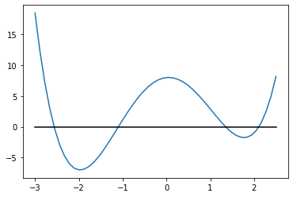

```
[-2.56274 -1.09634  1.35014  2.10892]
```

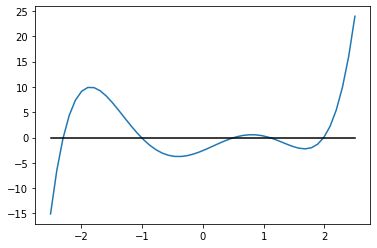

```
[-2.293 -1.009  0.516  1.095  1.988]
```

```python
%run Busq_Incre
```